# Final Project

STA3241.01 – April 27, 2020

Luiz Gustavo Fagundes Malpele, Cindy Nguyen, Isabel Zimmerman

# Introduction

The aim of this report was to predict early and mid career pay for college graduates from data collected on independent variables such as: tuition costs, school enrollment size, percentage STEM of majors, percentage of minority students, etc. After a robust exploratory data analysis, various regression algorithms were created utilizing the libraries `tidyverse`, `caret`, `DataExplorer`, `fastDummies`, `leaps`, `cowplot`, and `GGally`. All of the R code can be found at the GitHub [here](https://github.com/luizmalpele/stats_learning_project/).

# Dataset

We began by importing processed data from TidyTuesday, which can also be found [here](https://github.com/luizmalpele/stats_learning_project/blob/master/data/data.Rmd).

From this data, we transformed all minority variables into percentages of total enrollment, and took the log of the following variables: early career pay, mid career pay, in state tuition, out of state tuition, room and board, and total enrollment. This was to create more normal distributions in the data and possibly remove heteroscedasticity. With the addition of these two features in the data, some of the models (particularly linear models) may improve in predictive power.

```
## Rows: 2,973
## Columns: 27
## $ name                      <fct> Aaniiih Nakoda College, Abilene Christian...
## $ state                     <fct> Montana, Texas, Georgia, Minnesota, Calif...
## $ state_code                <fct> MT, TX, GA, MN, CA, CO, NY, NY, MI, VA, F...
## $ type                      <fct> Public, Private, Public, For Profit, For ...
## $ degree_length             <fct> 2 Year, 4 Year, 2 Year, 2 Year, 4 Year, 4...
## $ room_and_board            <int> NA, 10350, 8474, NA, 16648, 8782, 16030, ...
## $ in_state_tuition          <int> 2380, 34850, 4128, 17661, 27810, 9440, 38...
## $ in_state_total            <int> 2380, 45200, 12602, 17661, 44458, 18222, ...
## $ out_of_state_tuition      <int> 2380, 34850, 12550, 17661, 27810, 20456, ...
## $ out_of_state_total        <int> 2380, 45200, 21024, 17661, 44458, 29238, ...
## $ total_enrollment          <int> 291, 4427, 3458, 127, 15212, 3154, 7610, ...
## $ rank                      <int> NA, NA, NA, NA, NA, 16, NA, NA, NA, NA, 1...
## $ early_career_pay          <int> NA, NA, NA, NA, NA, 44400, NA, NA, NA, NA...
## $ mid_career_pay            <int> NA, NA, NA, NA, NA, 81400, NA, NA, NA, NA...
## $ make_world_better_percent <int> NA, NA, NA, NA, NA, 56, NA, NA, NA, NA, 8...
## $ stem_percent              <int> NA, NA, NA, NA, NA, 3, NA, NA, NA, NA, 5,...
## $ women                     <int> 178, 2562, 1822, 28, 8815, 1728, 5523, 24...
## $ native_american           <int> 256, 18, 9, 1, 70, 37, 10, 18, 3, 7, NA, ...
## $ asian                     <int> 0, 46, 36, 10, 1092, 37, 554, 38, 10, 19,...
## $ black                     <int> 0, 387, 407, 14, 999, 191, 857, 126, 153,...
## $ hispanic                  <int> 2, 582, 197, 6, 1383, 812, 1007, 135, 80,...
## $ pacific_islander          <int> 0, 0, 1, 3, 75, 10, 6, 2, 0, 1, NA, 2, 3,...
## $ white                     <int> 33, 2959, 2728, 80, 3456, 1776, 4058, 381...
## $ two_more_races            <int> 0, 179, 30, 1, 312, 126, 153, 76, 54, 11,...
## $ unkown                    <int> 0, 71, 1, 12, 2652, 165, 529, 31, 174, 3,...
## $ foreign                   <int> 0, 185, 49, 0, 5173, 0, 436, 9, 1, 0, NA,...
## $ total_minority            <int> 258, 1212, 680, 35, 3931, 1213, 2587, 395...
```

## Data Dictionary

| Field Name | Description | Data Type | Number of Observations |
| --- | --- | --- | --- |
| name | Institution Name | factor | 486 |
| state_code | State Abbreviation | factor | 486 |
| make_world_better_percent | Percent of alumni who think they are making the world a better place | integer | 486 |
| room_and_board | Room and board in USD | integer | 486 |
| ln_room_and_board | Natural Log of Room and board in U$D | double | 486 |
| early_career_pay | Estimated early career pay in USD | int | 486 |
| ln_early_career_pay | Natural log of estimated early career pay in USD | double | 486 |
| mid_career_pay | Estimated mid career pay in USD | int | 486 |
| ln_mid_career_pay | Natural log of estimated mid career pay in USD | double | 486 |
| total_enrollment | Total enrollment of students | double | 486 |
| ln_total_enrollment | Natural Log of Total enrollment of students | double | 486 |
| out_of_state_tuition | Tuition for out-of-state residents in USD | integer | 486 |
| ln_out_of_state_tuition | Natural Log of Tuition for out-of-state residents in USD | double | 486 |
| in_of_state_tuition | Tuition for in-of-state residents in USD | integer | 486 |
| ln_in_of_state_tuition | Natural Log of Tuition for in-of-state residents in USD | double | 486 |
| stem_percent | Percent of student body in STEM | double | 486 |
| private | Type: 0 for Public, 1 for Private | integer | 486 |
| asian_ratio | Percentage of Asian Students | double | 486 |
| black_ratio | Percentage of Black Students | double | 486 |
| minority_ratio | Percentage of all Minorities Combined | double | 486 |
| hispanic_ratio | Percentage of Hispanic Students | double | 486 |
| women_ratio | Percentage of Women Students | double | 486 |
| tuition_ratio | Out-of-State Tuition and In-State Tuition Ratio | double | 486 |

## Exploratory Data Analysis

The first step was to use the `DataExplorer` package to automatically create an EDA. This report can be found [here](https://github.com/luizmalpele/stats_learning_project/blob/master/project/EDA_report.html). Using this process was preferred as it automatically created all the univariate distributions and correlation matricies for the variables. This way, we were able to focus on creating more complex explorations that were fine-tuned to the question we wanted to answer.

```r
#create_report(college_dataset)
```

The first look into the data was to see how the distribution of pay shifted from early to mid career. We could tell that the distribution became wider and right-skewed for mid career pay and was higher on average; the mean early pay was $51,000 whereas the mid career pay average was $92,000.

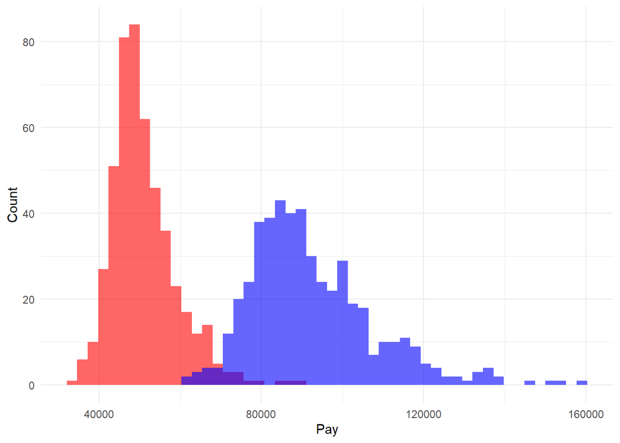

```r
college_dataset %>%
  ggplot() +
  geom_histogram(mapping = aes(x = early_career_pay),
                 fill = "red",
                 alpha = 0.6,
                 bins = 50) +
  geom_histogram(mapping = aes(x = mid_career_pay),
                 fill = "blue",
                 alpha = 0.6,
                 bins = 50) +
  xlab("Pay") +
  ylab("Count") +
  theme_minimal()
```

```r
paste("Mean early career pay:", mean(college_dataset$early_career_pay), "Mean mid career pay: ", mean(college_dataset$mid_career_pay))
```

```
## [1] "Mean early career pay: 51024.8971193416 Mean mid career pay:  92407.2016460905"
```

[figure not shown]

```r
college_dataset_shrinked <- college_dataset %>%
  select(ln_early_career_pay,
         asian_ratio,
         ln_out_of_state_tuition,
         stem_percent,
         ln_room_and_board,
         private,
         black_ratio,
         ln_total_enrollment,
         women_ratio)
```

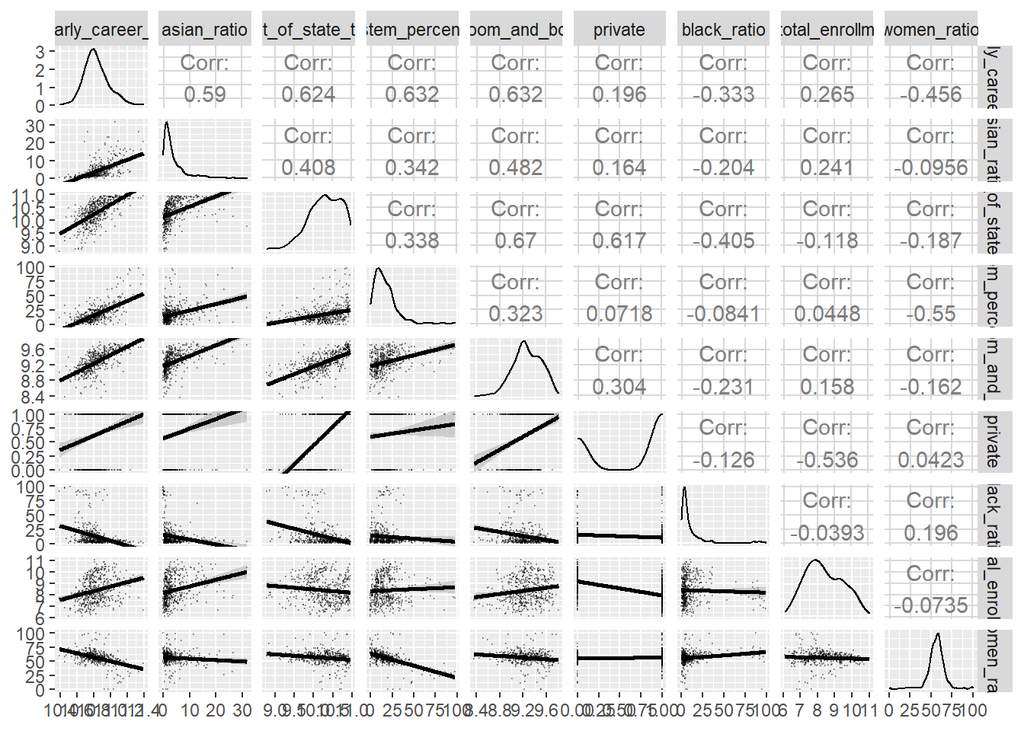

```r
ggpairs(data = college_dataset_shrinked, lower = list(continuous = wrap("smooth", alpha = 0.3, size=0.1)))
```

Separating the data into Train and Test

```r
set.seed(123)
train_control <-  trainControl(method = "cv", number = 10)

inTrain <- createDataPartition(y = college_dataset_shrinked$ln_early_career_pay, p = 0.8, list = FALSE)

train_data <- college_dataset_shrinked[inTrain , ]
test_data <- college_dataset_shrinked[-inTrain , ]
```

This command separates 80% of the data into a training set, and other 20% into a testing set. This is done to avoid overfitting and it is preferable to perform the final model selection with an out of sample criterion.

**Variables selection**

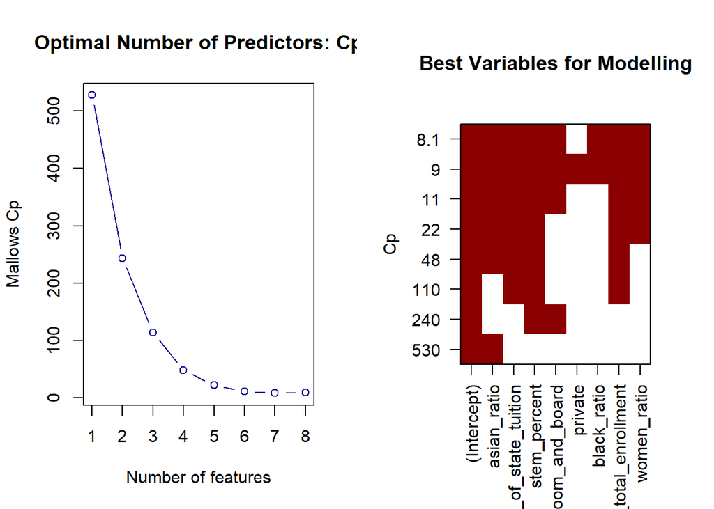

```r
#Separating the data
sub_fit_pay <- regsubsets(ln_early_career_pay ~
                            asian_ratio +
                            ln_out_of_state_tuition +
                            stem_percent +
                            ln_room_and_board +
                            private +
                            black_ratio +
                            ln_total_enrollment +
                            women_ratio,
                          data = train_data)

best_summary <- summary(sub_fit_pay)

#Plots
par(mfrow = c(1,2))
plot(best_summary$cp, xlab = "Number of features", ylab = "Mallows Cp", main = "Optimal Number of Predictors: Cp", col = "dark blue", type = "b")

plot(sub_fit_pay, scale = "Cp", main = "Best Variables for Modelling", col = "dark red")
```

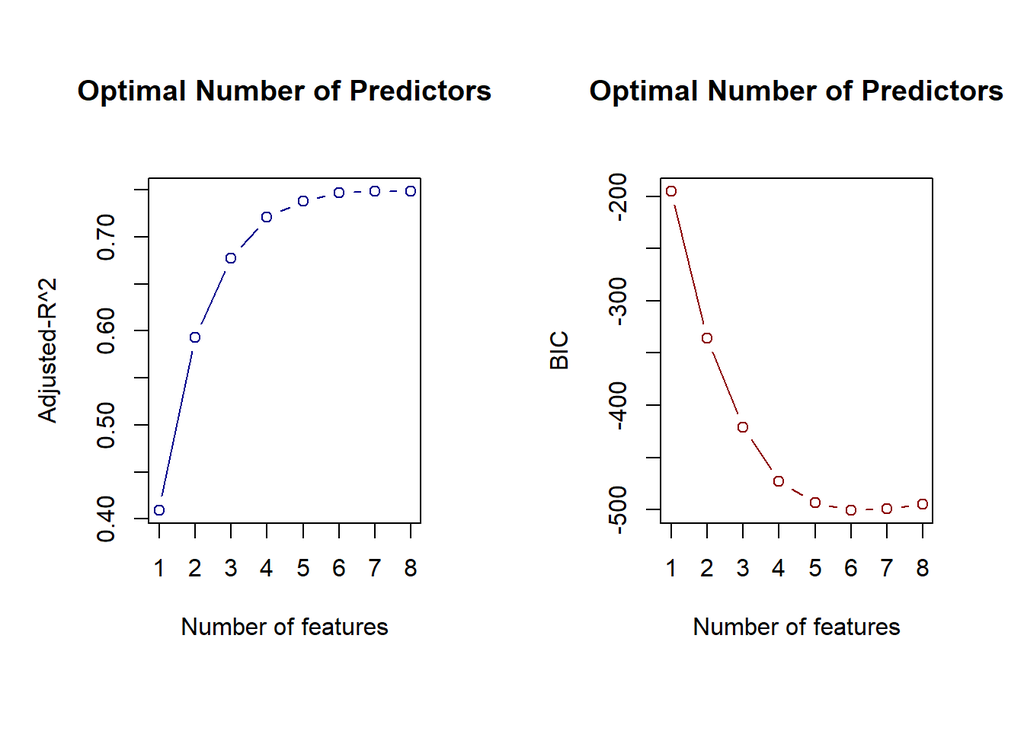

```r
par(mfrow = c(1,2))

plot(best_summary$adjr2, xlab = "Number of features", ylab = "Adjusted-R^2", main = "Optimal Number of Predictors", col = "dark blue", type = "b")

plot(best_summary$bic, xlab = "Number of features", ylab = "BIC", main = "Optimal Number of Predictors", col = "dark red", type = "b")
```

# Modeling With other Techniques

## PCA

```r
glm_pca_model <- train(ln_early_career_pay ~ . ,
                 data = train_data,
                 method = "glm",
                 preProcess = "pca",
                 trControl = train_control)
glm_pca_model
```

```
## Generalized Linear Model
##
## 391 samples
##   8 predictor
##
## Pre-processing: principal component signal extraction (8), centered (8),
##  scaled (8)
## Resampling: Cross-Validated (10 fold)
## Summary of sample sizes: 352, 352, 353, 352, 351, 353, ...
## Resampling results:
##
##   RMSE      Rsquared   MAE
##   0.075609  0.7469513  0.05634975
```

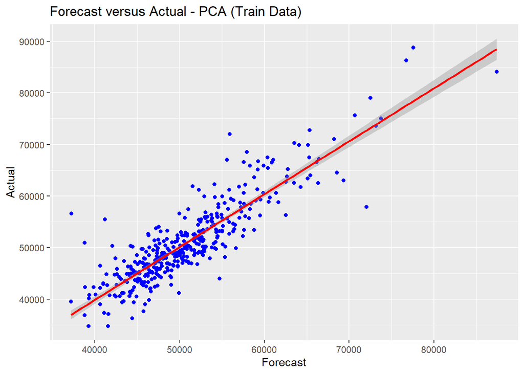

```r
#Training Data for PCA
pca_train_data <- predict(glm_pca_model)

unlog_forecast_pca <- exp(pca_train_data)

unlog_actual_pca <- exp(train_data$ln_early_career_pay)

ggplot(train_data, aes(x = unlog_forecast_pca, y = unlog_actual_pca),alpha = 0.6) +
  geom_point(color = "Blue") +
  geom_smooth(method = lm, color = "Red") +
  labs(title = "Forecast versus Actual - PCA (Train Data)", x = "Forecast", y = "Actual")
```

```r
pca_test_data <- predict(glm_pca_model, test_data)

RMSE2 <- mean((pca_test_data - test_data$ln_early_career_pay)^2)

RMSE2
```

```
## [1] 0.005791636
```

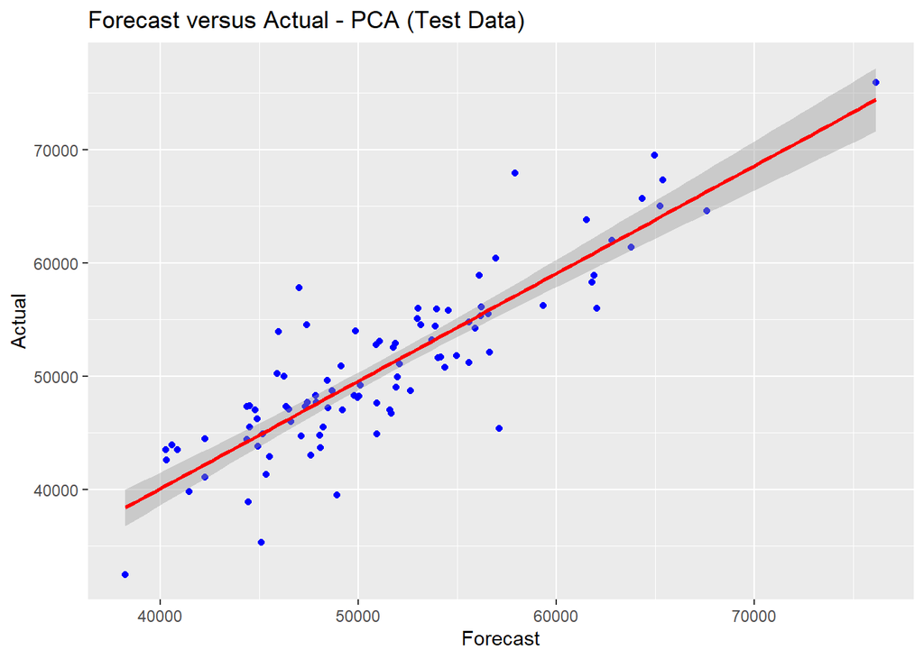

```r
#Test Data
unlog_forecast_pca <- exp(pca_test_data)

unlog_actual_pca <- exp(test_data$ln_early_career_pay)

ggplot(test_data, aes(x = unlog_forecast_pca, y = unlog_actual_pca),alpha = 0.6) +
  geom_point(color = "Blue") +
  geom_smooth(method = lm, color = "Red") +
  labs(title = "Forecast versus Actual - PCA (Test Data)", x = "Forecast", y = "Actual")
```

## Simple Linear Regression

```r
earlypay_lm <- lm(ln_early_career_pay ~  asian_ratio +
                    ln_out_of_state_tuition +
                    stem_percent +
                    ln_room_and_board +
                    black_ratio +
                    ln_total_enrollment +
                    women_ratio,
                  data = train_data)
summary(earlypay_lm)
```

```
##
## Call:
## lm(formula = ln_early_career_pay ~ asian_ratio + ln_out_of_state_tuition +
##     stem_percent + ln_room_and_board + black_ratio + ln_total_enrollment +
##     women_ratio, data = train_data)
##
## Residuals:
##      Min       1Q   Median       3Q      Max
## -0.22804 -0.04682 -0.00576  0.04173  0.42766
##
## Coefficients:
##                           Estimate Std. Error t value Pr(>|t|)
## (Intercept)              8.7878428  0.1612431  54.501  < 2e-16 ***
## asian_ratio              0.0080860  0.0010833   7.464 5.68e-13 ***
## ln_out_of_state_tuition  0.1011475  0.0140184   7.215 2.91e-12 ***
## stem_percent             0.0029594  0.0003463   8.546 3.07e-16 ***
## ln_room_and_board        0.0880747  0.0221317   3.980 8.26e-05 ***
## black_ratio             -0.0004816  0.0002257  -2.134   0.0335 *
## ln_total_enrollment      0.0261983  0.0039293   6.667 9.11e-11 ***
## women_ratio             -0.0019716  0.0003954  -4.986 9.34e-07 ***
## ---
## Signif. codes:  0 '***' 0.001 '**' 0.01 '*' 0.05 '.' 0.1 ' ' 1
##
## Residual standard error: 0.0751 on 383 degrees of freedom
## Multiple R-squared:  0.7532, Adjusted R-squared:  0.7487
## F-statistic:   167 on 7 and 383 DF,  p-value: < 2.2e-16
```

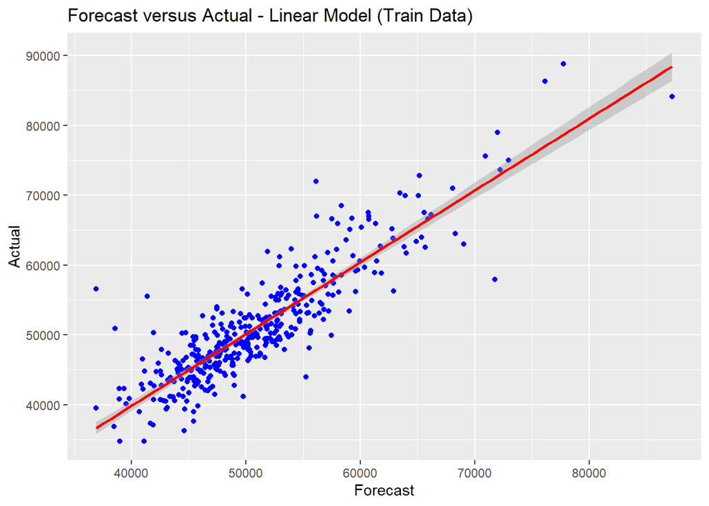

```r
#Training Data for Linear Model
lm_ep_train_data <- predict(earlypay_lm)

unlog_forecast_lm <- exp(lm_ep_train_data)

unlog_actual_lm <- exp(train_data$ln_early_career_pay)

ggplot(train_data, aes(x = unlog_forecast_lm, y = unlog_actual_lm),alpha = 0.6) +
  geom_point(color = "Blue") +
  geom_smooth(method = lm, color = "Red") +
  labs(title = "Forecast versus Actual - Linear Model (Train Data)", x = "Forecast", y = "Actual")
```

```r
#Testing Data on Linear Model
lm_test_data <- predict(earlypay_lm, test_data)

RMSE2 <- mean((lm_test_data - test_data$ln_early_career_pay)^2)

RMSE2
```

```
## [1] 0.005810831
```

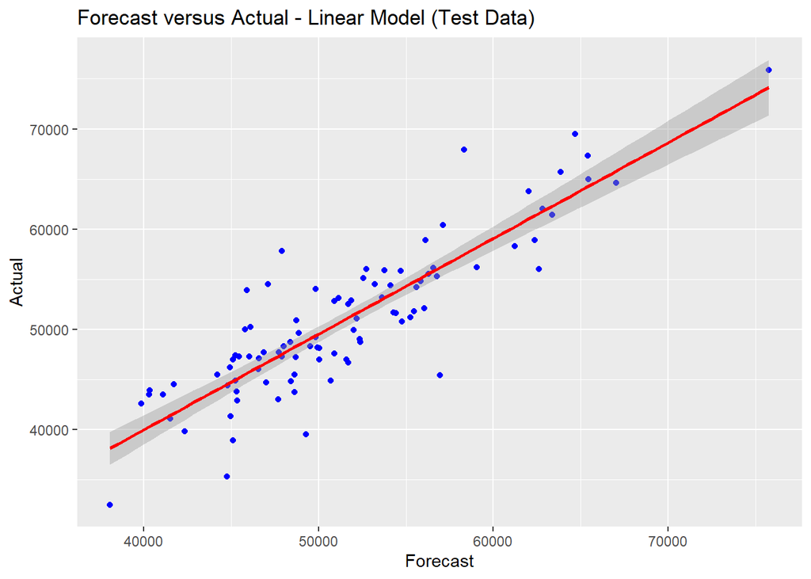

```r
#Test Data
unlog_forecast_lm <- exp(lm_test_data)

unlog_actual_lm <- exp(test_data$ln_early_career_pay)

ggplot(test_data, aes(x = unlog_forecast_lm, y = unlog_actual_lm),alpha = 0.6) +
  geom_point(color = "Blue") +
  geom_smooth(method = lm, color = "Red") +
  labs(title = "Forecast versus Actual - Linear Model (Test Data)", x = "Forecast", y = "Actual")
```

## Random Forest

```r
oob <- trainControl(method = "oob")
cv_5 <- trainControl(method = "cv", number = 5)
rf_grid <- expand.grid(mtry = 1:10)

set.seed(825)
rf_model <- train(ln_early_career_pay ~ ., data = train_data,
                     method = "rf",
                     trControl = oob,
                     verbose = FALSE,
                     tuneGrid = rf_grid)
# print results
rf_model
```

```
## Random Forest
##
## 391 samples
##   8 predictor
##
## No pre-processing
## Resampling results across tuning parameters:
##
##   mtry  RMSE        Rsquared
##    1    0.07467574  0.7509320
##    2    0.06943366  0.7846728
##    3    0.06959919  0.7836449
##    4    0.06980937  0.7823362
##    5    0.07078309  0.7762218
##    6    0.07048582  0.7780975
##    7    0.07100188  0.7748363
##    8    0.07076411  0.7763418
##    9    0.07103969  0.7745964
##   10    0.07071541  0.7766495
##
## RMSE was used to select the optimal model using the smallest value.
## The final value used for the model was mtry = 2.
```

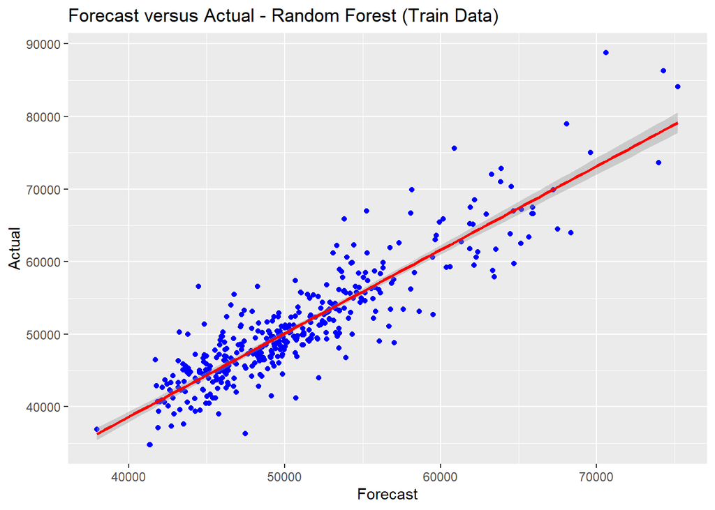

```r
#Training Data for Random Forest
random_forest_data <- predict(rf_model)

unlog_forecast_rf <- exp(random_forest_data)

unlog_actual_rf <- exp(train_data$ln_early_career_pay)

ggplot(train_data, aes(x = unlog_forecast_rf, y = unlog_actual_rf),alpha = 0.6) +
  geom_point(color = "Blue") +
  geom_smooth(method = lm, color = "Red") +
  labs(title = "Forecast versus Actual - Random Forest (Train Data)", x = "Forecast", y = "Actual")
```

```r
rf_test <- predict(rf_model, test_data)

RMSE2 <- mean((rf_test - test_data$ln_early_career_pay)^2)

RMSE2
```

```
## [1] 0.00481415
```

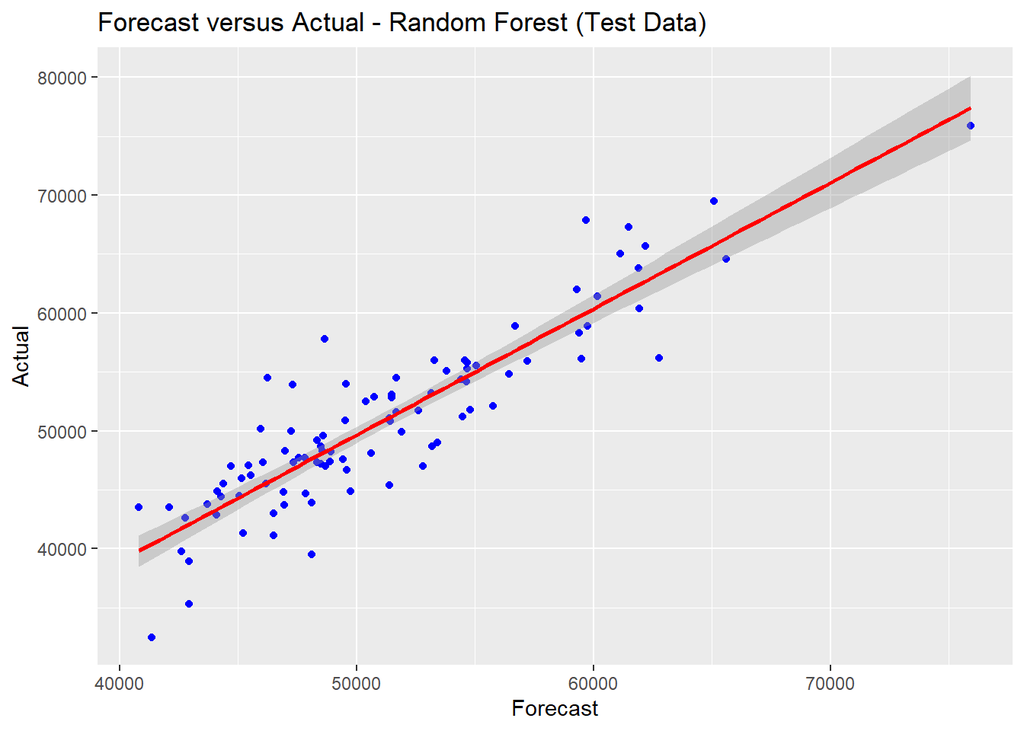

```r
#Test Data
unlog_forecast_rf <- exp(rf_test)

unlog_actual_rf <- exp(test_data$ln_early_career_pay)

ggplot(test_data, aes(x = unlog_forecast_rf, y = unlog_actual_rf),alpha = 0.6) +
  geom_point(color = "Blue") +
  geom_smooth(method = lm, color = "Red") +
  labs(title = "Forecast versus Actual - Random Forest (Test Data)", x = "Forecast", y = "Actual")
```

```r
calc_acc <- function(actual, predicted) {
  mean(actual == predicted)
}
```

## SVM

Preprocessing

```r
set.seed(123)
college_dataset_shrinked <- na.omit(college_dataset_shrinked)


#train control
tr_control <- trainControl(method = "cv", number = 10)

# grid
tGrid <- expand.grid(C = c(0.01, 0.05, 0.1, 0.25, 0.5, 0.75, 1, 1.25, 1.5, 1.75, 2, 5))
```

Model

```r
# model 1:
svm_model_1 <- train(ln_early_career_pay ~ .,
  data = train_data,
  method = "svmLinear",
  tuneGrid = tGrid,
  trControl = tr_control,
  metric = "RMSE",
  preProcess = c("center", "scale")
)
svm_model_1
```

```
## Support Vector Machines with Linear Kernel
##
## 391 samples
##   8 predictor
##
## Pre-processing: centered (8), scaled (8)
## Resampling: Cross-Validated (10 fold)
## Summary of sample sizes: 352, 352, 352, 351, 353, 351, ...
## Resampling results across tuning parameters:
##
##   C     RMSE        Rsquared   MAE
##   0.01  0.07623164  0.7412840  0.05667222
##   0.05  0.07647969  0.7381777  0.05717968
##   0.10  0.07662913  0.7379568  0.05733411
##   0.25  0.07683603  0.7371850  0.05747306
##   0.50  0.07693462  0.7368597  0.05749893
##   0.75  0.07687185  0.7370580  0.05747186
##   1.00  0.07688417  0.7370161  0.05747874
##   1.25  0.07688296  0.7370413  0.05747725
##   1.50  0.07689231  0.7369424  0.05748752
##   1.75  0.07691803  0.7369586  0.05749858
##   2.00  0.07692059  0.7369546  0.05749360
##   5.00  0.07694807  0.7367786  0.05749538
##
## RMSE was used to select the optimal model using the smallest value.
## The final value used for the model was C = 0.01.
```

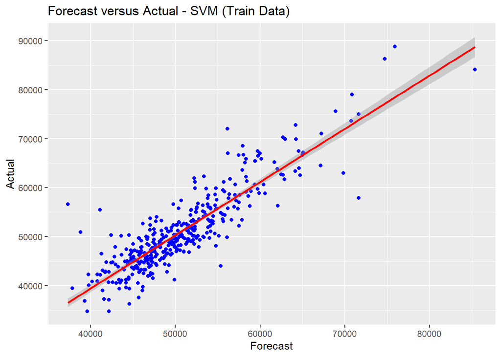

```r
#Training Data
svm_train_data <- predict(svm_model_1)

unlog_forecast_svm <- exp(svm_train_data)

unlog_actual_svm <- exp(train_data$ln_early_career_pay)

ggplot(train_data, aes(x = unlog_forecast_svm, y = unlog_actual_svm),alpha = 0.6) +
  geom_point(color = "Blue") +
  geom_smooth(method = lm, color = "Red") +
  labs(title = "Forecast versus Actual - SVM (Train Data)", x = "Forecast", y = "Actual")
```

```r
svm_test_data <- predict(svm_model_1, test_data)

RMSE2 <- mean((svm_test_data - test_data$ln_early_career_pay)^2)

RMSE2
```

```
## [1] 0.00574263
```

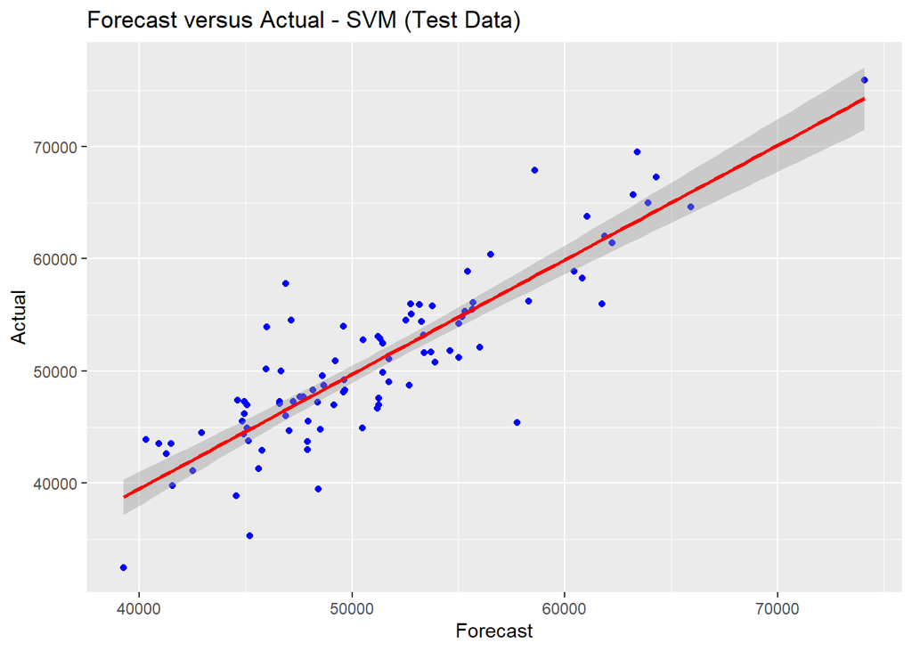

```r
#Test Data
unlog_forecast_svm <- exp(svm_test_data)

unlog_actual_svm <- exp(test_data$ln_early_career_pay)

ggplot(test_data, aes(x = unlog_forecast_svm, y = unlog_actual_svm),alpha = 0.6) +
  geom_point(color = "Blue") +
  geom_smooth(method = lm, color = "Red") +
  labs(title = "Forecast versus Actual - SVM (Test Data)", x = "Forecast", y = "Actual")
```

```r
set.seed(981)
#10 fold CV
train_control <-  trainControl(method = "cv", number = 10)
#Grid
grid <- seq(-2,10,length=100)

lasso_model <- train(ln_early_career_pay ~ .,
                     data = train_data,
                     method = "glmnet",
                     trControl = train_control,
                     metric =  "Rsquared",
                     tune_Grid = expand.grid(alpha = 1, lambda = grid))
lasso_model
```

```
## glmnet
##
## 391 samples
##   8 predictor
##
## No pre-processing
## Resampling: Cross-Validated (10 fold)
## Summary of sample sizes: 353, 351, 353, 351, 353, 352, ...
## Resampling results across tuning parameters:
##
##   alpha  lambda        RMSE        Rsquared   MAE
##   0.10   0.0001917911  0.07610813  0.7507506  0.05700358
##   0.10   0.0019179111  0.07609265  0.7508827  0.05699603
##   0.10   0.0191791107  0.07624528  0.7527662  0.05706853
##   0.55   0.0001917911  0.07612391  0.7505937  0.05702869
##   0.55   0.0019179111  0.07612207  0.7508329  0.05703123
##   0.55   0.0191791107  0.07865899  0.7481342  0.05920959
##   1.00   0.0001917911  0.07613395  0.7505634  0.05703904
##   1.00   0.0019179111  0.07618074  0.7507277  0.05709597
##   1.00   0.0191791107  0.08313875  0.7328813  0.06322442
##
## Rsquared was used to select the optimal model using the largest value.
## The final values used for the model were alpha = 0.1 and lambda = 0.01917911.
```

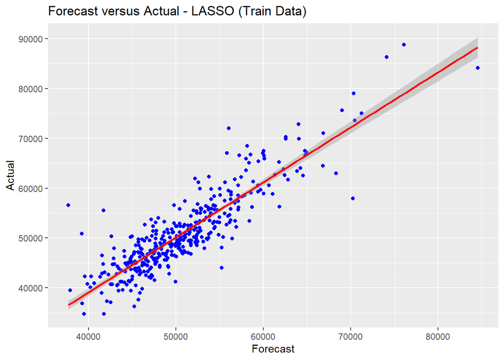

```r
#Training Data
lasso_train_data <- predict(lasso_model)

unlog_forecast_lasso <- exp(lasso_train_data)

unlog_actual_lasso <- exp(train_data$ln_early_career_pay)

ggplot(train_data, aes(x = unlog_forecast_lasso, y = unlog_actual_lasso),alpha = 0.6) +
  geom_point(color = "Blue") +
  geom_smooth(method = lm, color = "Red") +
  labs(title = "Forecast versus Actual - LASSO (Train Data)", x = "Forecast", y = "Actual")
```

```r
test_lasso <- predict(lasso_model, test_data)

RMSE2 <- mean((test_lasso - test_data$ln_early_career_pay)^2)

RMSE2
```

```
## [1] 0.005811474
```

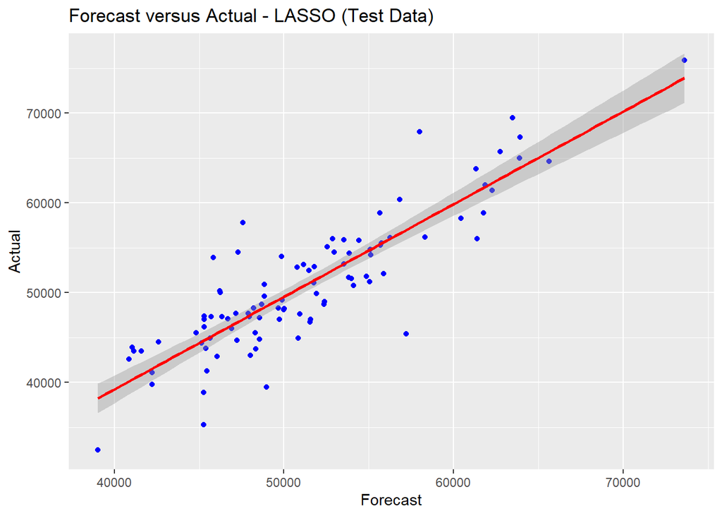

```r
#Test Data
unlog_forecast_lasso <- exp(test_lasso)

unlog_actual_lasso <- exp(test_data$ln_early_career_pay)

ggplot(test_data, aes(x = unlog_forecast_lasso, y = unlog_actual_lasso),alpha = 0.6) +
  geom_point(color = "Blue") +
  geom_smooth(method = lm, color = "Red") +
  labs(title = "Forecast versus Actual - LASSO (Test Data)", x = "Forecast", y = "Actual")
```

```r
set.seed(981)
ridge_model <- train(ln_early_career_pay ~ .,
                     data = train_data,
                     method = "glmnet",
                     trControl = train_control,
                     metric =  "Rsquared",
                     tune_Grid = expand.grid(alpha = 0, lambda = grid))

ridge_model
```

```
## glmnet
##
## 391 samples
##   8 predictor
##
## No pre-processing
## Resampling: Cross-Validated (10 fold)
## Summary of sample sizes: 353, 351, 353, 351, 353, 352, ...
## Resampling results across tuning parameters:
##
##   alpha  lambda        RMSE        Rsquared   MAE
##   0.10   0.0001917911  0.07610813  0.7507506  0.05700358
##   0.10   0.0019179111  0.07609265  0.7508827  0.05699603
##   0.10   0.0191791107  0.07624528  0.7527662  0.05706853
##   0.55   0.0001917911  0.07612391  0.7505937  0.05702869
##   0.55   0.0019179111  0.07612207  0.7508329  0.05703123
##   0.55   0.0191791107  0.07865899  0.7481342  0.05920959
##   1.00   0.0001917911  0.07613395  0.7505634  0.05703904
##   1.00   0.0019179111  0.07618074  0.7507277  0.05709597
##   1.00   0.0191791107  0.08313875  0.7328813  0.06322442
##
## Rsquared was used to select the optimal model using the largest value.
## The final values used for the model were alpha = 0.1 and lambda = 0.01917911.
```

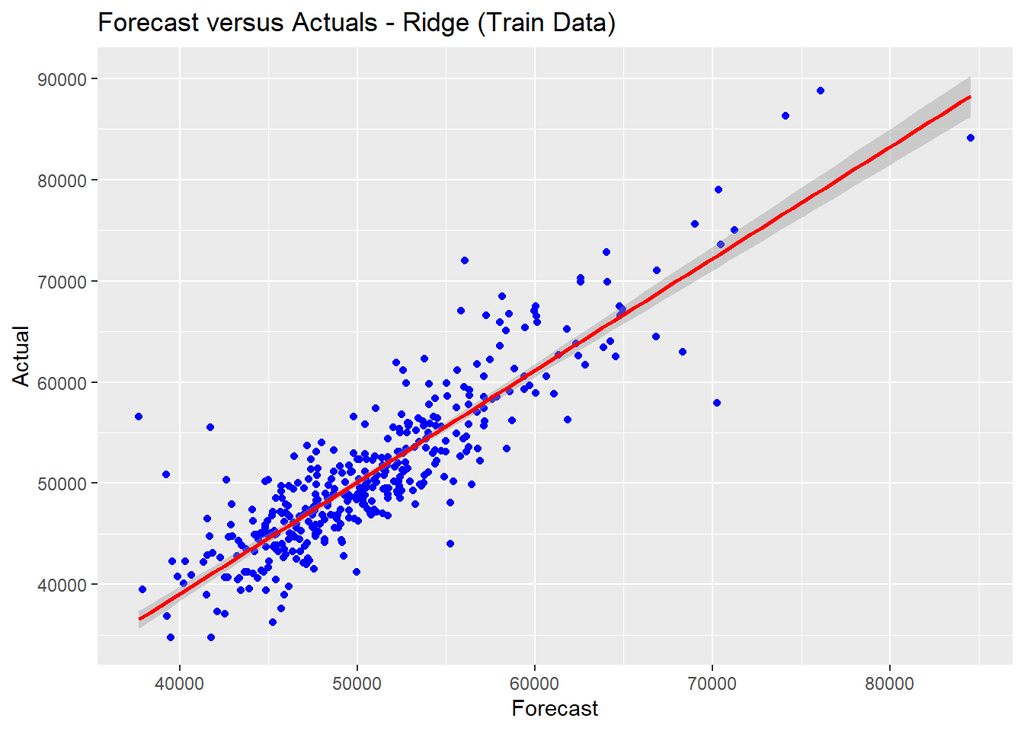

```r
#Training Data
ridge_train_data <- predict(ridge_model)

unlog_forecast_ridge <- exp(ridge_train_data)

unlog_actual <- exp(train_data$ln_early_career_pay)

ggplot(train_data, aes(x = unlog_forecast_ridge, y = unlog_actual),alpha = 0.6) +
  geom_point(color = "Blue") +
  geom_smooth(method = lm, color = "Red") +
  labs(title = "Forecast versus Actuals - Ridge (Train Data)", x = "Forecast", y = "Actual")
```

```r
test_ridge_data <- predict(ridge_model, test_data)

RMSE2 <- mean((test_ridge_data - test_data$ln_early_career_pay)^2)

RMSE2
```

```
## [1] 0.005811474
```

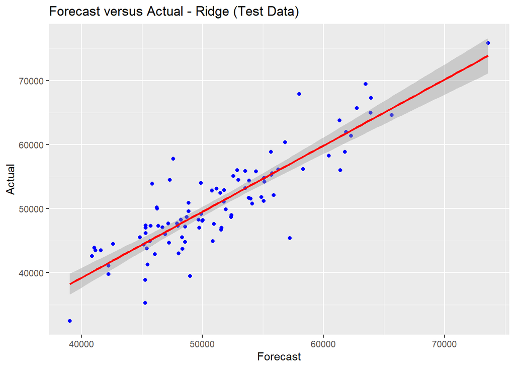

```r
#Test Data
unlog_forecast_ridge <- exp(test_ridge_data)

unlog_actual_ridge <- exp(test_data$ln_early_career_pay)

ggplot(test_data, aes(x = unlog_forecast_ridge, y = unlog_actual_ridge),alpha = 0.6) +
  geom_point(color = "Blue") +
  geom_smooth(method = lm, color = "Red") +
  labs(title = "Forecast versus Actual - Ridge (Test Data)", x = "Forecast", y = "Actual")
```